# IS 607 - Project 2

Suman K Polavarapu

Saturday, March 14, 2015

# Activity Definition:

*Perform exploratory data analysis that compares the below data sets.Use ggplot2 with R and draw conclusions from analysis*

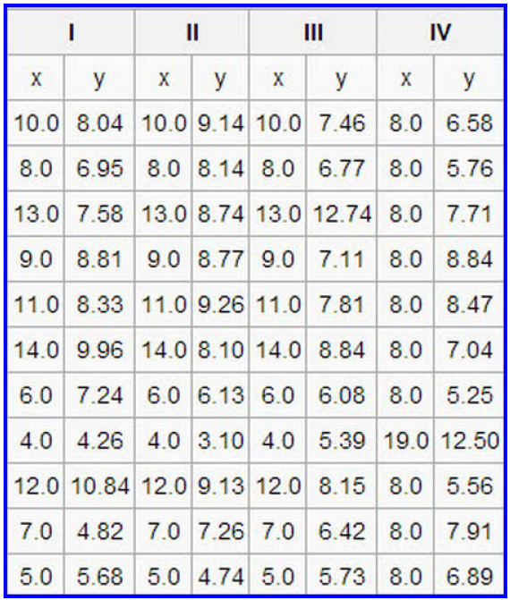

## Setup:

*Load the required libraries*

```r
library(ggplot2)
library(plyr)
```

*Load the csv file of the data sets into a dataframe*

```r
dataframe <- read.table("IS_607_Proj_2.csv", header = TRUE, sep = ",", stringsAsFactors=TRUE)
str(dataframe)
```

```
## 'data.frame':    44 obs. of  3 variables:
##  $ dataset: Factor w/ 4 levels "set1","set2",..: 1 2 3 4 1 2 3 4 1 2 ...
##  $ x      : num  10 10 10 8 8 8 8 8 13 13 ...
##  $ y      : num  8.04 9.14 7.46 6.58 6.95 8.14 6.77 5.76 7.58 8.74 ...
```

## Analysis:

### Summary stats group by each dataset

```r
aggregate(cbind(x,y) ~ dataset, data = dataframe, summary)
```

```
##   dataset x.Min. x.1st Qu. x.Median x.Mean x.3rd Qu. x.Max. y.Min.
## 1    set1    4.0       6.5      9.0    9.0      11.5   14.0  4.260
## 2    set2    4.0       6.5      9.0    9.0      11.5   14.0  3.100
## 3    set3    4.0       6.5      9.0    9.0      11.5   14.0  5.390
## 4    set4    8.0       8.0      8.0    9.0       8.0   19.0  5.250
##   y.1st Qu. y.Median y.Mean y.3rd Qu. y.Max.
## 1     6.315    7.580  7.501     8.570 10.840
## 2     6.695    8.140  7.501     8.950  9.260
## 3     6.250    7.110  7.500     7.980 12.740
## 4     6.170    7.040  7.501     8.190 12.500
```

### Review the density of y and x values across all four sets

*Review the distribution of y values across all four sets*

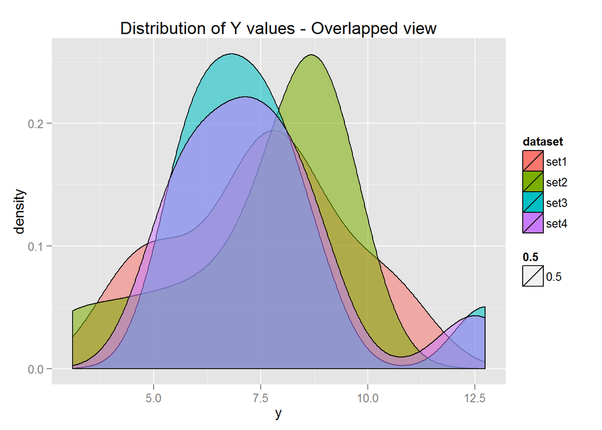

```r
ggplot(dataframe, aes(x=y, alpha=.5)) + geom_density(aes(fill=dataset)) + labs(title="Distribution of Y values - Overlapped view", xlab="y")
```

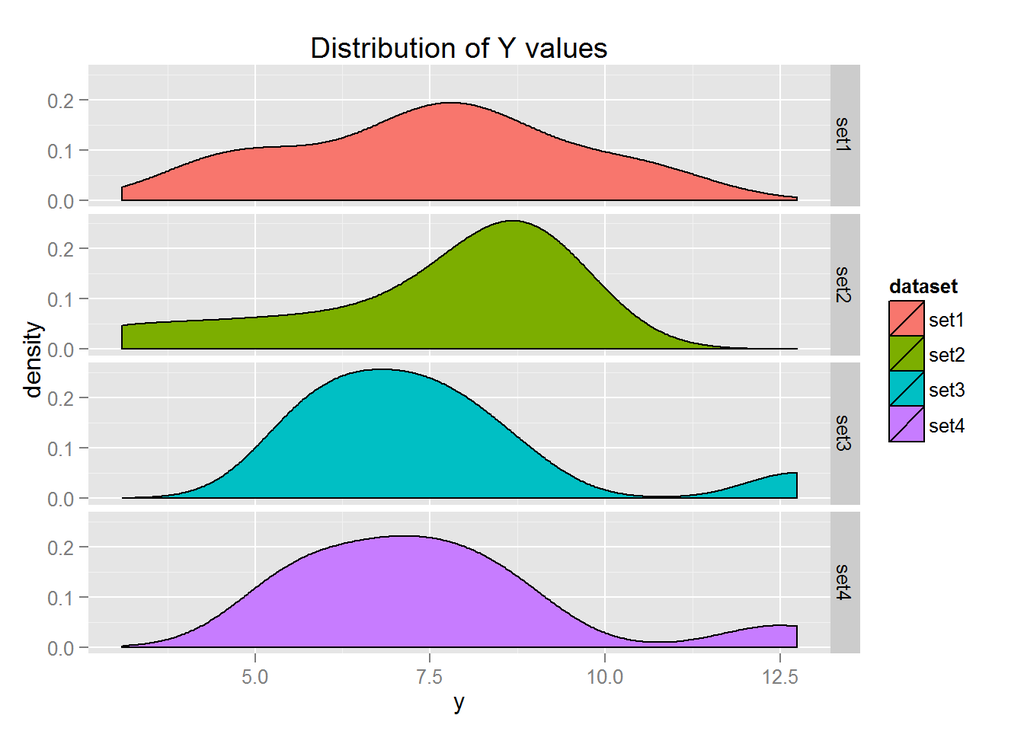

```r
ggplot(dataframe, aes(x=y)) + geom_density(aes(fill=dataset)) + labs(title="Distribution of Y values", xlab="y") + facet_grid(dataset~.)
```

> **Observation:** set1 and set2’s y values appears to have similarity. And set3 and set4’s y distribution appears similar

### Review the distribution of x values across all four sets

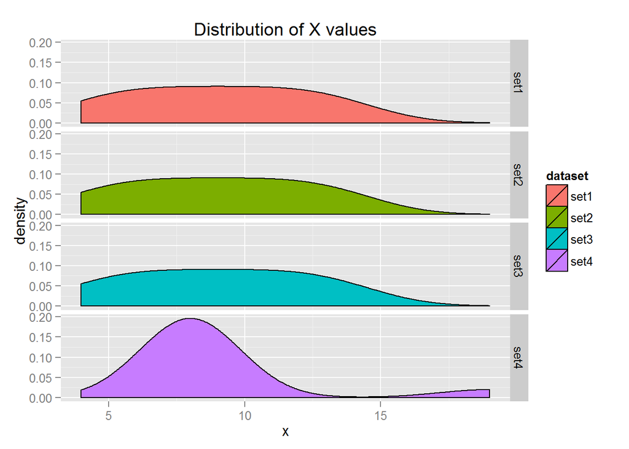

```r
ggplot(dataframe, aes(x=x)) + geom_density(aes(fill=dataset)) + labs(title="Distribution of X values", xlab="x") + facet_grid(dataset~.)
```

> **Observation:** x values distribution from set1, set2, and set3 appears similar. However, set4 is different here.

### Draw the Box plot for these sets and highlight if there are any outlier points in the given sets

*mutate the dataframe and add additional fields Q1, Q2, IQR, upper and lower limits for data points for all 4 sets*

```r
df.quartile <- ddply(dataframe, .(dataset), mutate, Q1=quantile(y, 1/4), Q3=quantile(y, 3/4), IQR=Q3-Q1, upper.limit=Q3+1.5*IQR, lower.limit=Q1-1.5*IQR)
str(df.quartile)
```

```
## 'data.frame':    44 obs. of  8 variables:
##  $ dataset    : Factor w/ 4 levels "set1","set2",..: 1 1 1 1 1 1 1 1 1 1 ...
##  $ x          : num  10 8 13 9 11 14 6 4 12 7 ...
##  $ y          : num  8.04 6.95 7.58 8.81 8.33 ...
##  $ Q1         : num  6.31 6.31 6.31 6.31 6.31 ...
##  $ Q3         : num  8.57 8.57 8.57 8.57 8.57 8.57 8.57 8.57 8.57 8.57 ...
##  $ IQR        : num  2.26 2.26 2.26 2.26 2.26 ...
##  $ upper.limit: num  12 12 12 12 12 ...
##  $ lower.limit: num  2.93 2.93 2.93 2.93 2.93 ...
```

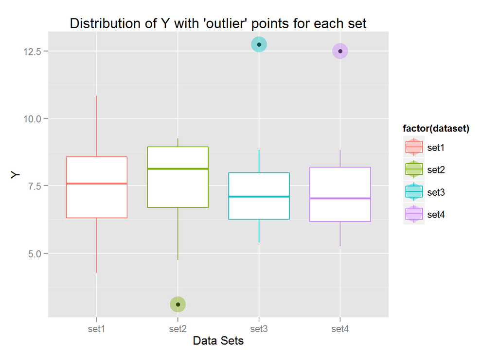

```r
ggplot() +
  geom_boxplot(data=df.quartile, aes(x=factor(dataset), y=y, color = factor(dataset))) +
  geom_point(data=df.quartile[df.quartile$y > df.quartile$upper.limit | df.quartile$y < df.quartile$lower.limit,], size=8, alpha=.4 ,aes( x=factor(dataset), y=y, color=factor(dataset))) +
  labs(title="Distribution of Y with 'outlier' points for each set", x="Data Sets", y="Y")
```

> **Observation:** set2, set3 and set4 has got outliers.

### Draw scatter plots for all sets and review.

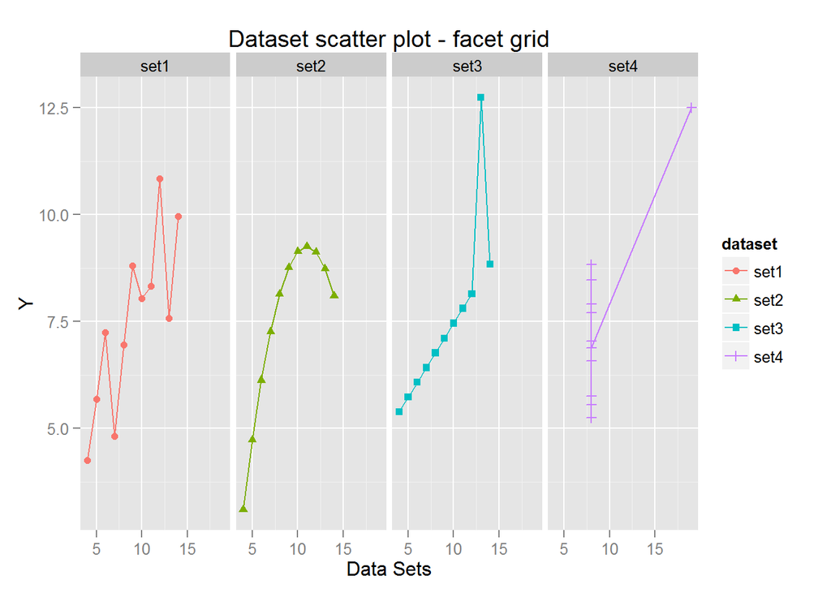

```r
ggplot(dataframe, aes(x=x, y=y, shape=dataset, color=dataset)) + geom_point(size=2) +  facet_grid(.~dataset) + geom_line() +
  labs(title="Dataset scatter plot - facet grid", x="Data Sets", y="Y")
```

*Draw a geom smooth - with lm*

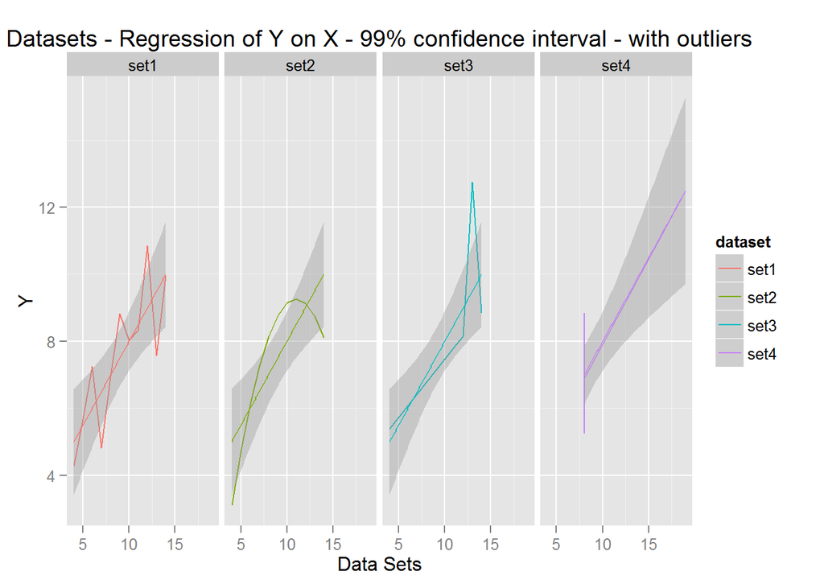

```r
ggplot(dataframe,aes(x=x, y=y, color=dataset)) + facet_grid(.~dataset)  + geom_line() + geom_smooth(method=lm) +
  labs(title="Datasets - Regression of Y on X - 99% confidence interval - with outliers", x="Data Sets", y="Y")
```

> **Observation:** All 4 sets appears to show some what similar trends. But we do have the outliers here.

### Remove the outliers and review.

```r
df_cleandata <- subset(df.quartile, y <= upper.limit & y >= df.quartile$lower.limit)

str(df_cleandata)
```

```
## 'data.frame':    41 obs. of  8 variables:
##  $ dataset    : Factor w/ 4 levels "set1","set2",..: 1 1 1 1 1 1 1 1 1 1 ...
##  $ x          : num  10 8 13 9 11 14 6 4 12 7 ...
##  $ y          : num  8.04 6.95 7.58 8.81 8.33 ...
##  $ Q1         : num  6.31 6.31 6.31 6.31 6.31 ...
##  $ Q3         : num  8.57 8.57 8.57 8.57 8.57 8.57 8.57 8.57 8.57 8.57 ...
##  $ IQR        : num  2.26 2.26 2.26 2.26 2.26 ...
##  $ upper.limit: num  12 12 12 12 12 ...
##  $ lower.limit: num  2.93 2.93 2.93 2.93 2.93 ...
```

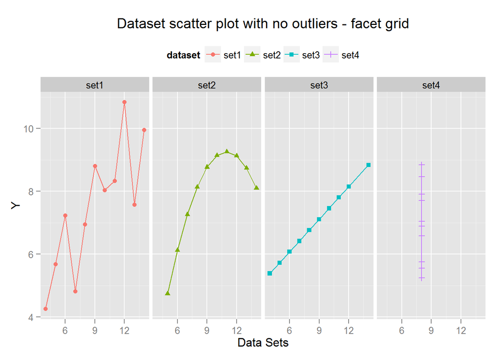

```r
#Draw the scatter plot facet grid with no outliers
ggplot(df_cleandata, aes(x=x, y=y, shape=dataset, color=dataset)) + geom_point(size=2) +  facet_grid(.~dataset) + geom_line() +
  labs(title="Dataset scatter plot with no outliers - facet grid", x="Data Sets", y="Y") + theme(legend.position="top")
```

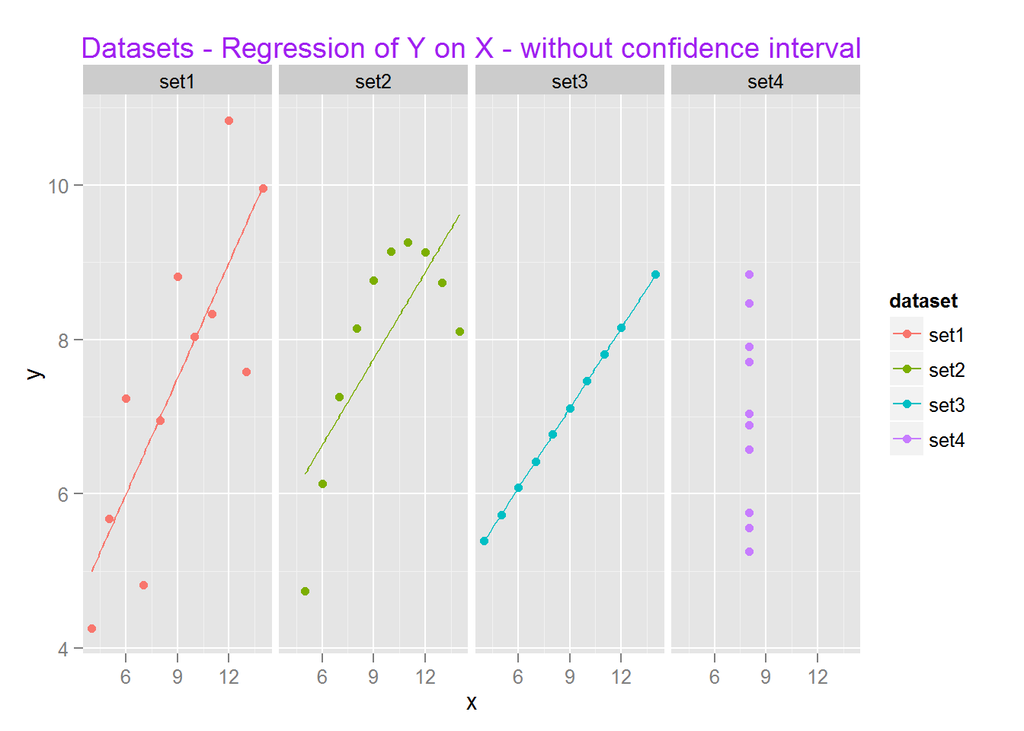

```r
#Regressions of y on x for each set with No confidence region
ggplot(df_cleandata,aes(x=x, y=y, color=dataset)) + geom_point(size=2) +  geom_smooth(method=lm, se=FALSE) +  facet_grid(.~dataset) + labs(title="Datasets - Regression of Y on X - without confidence interval") + theme(plot.title = element_text(colour = "purple"))
```

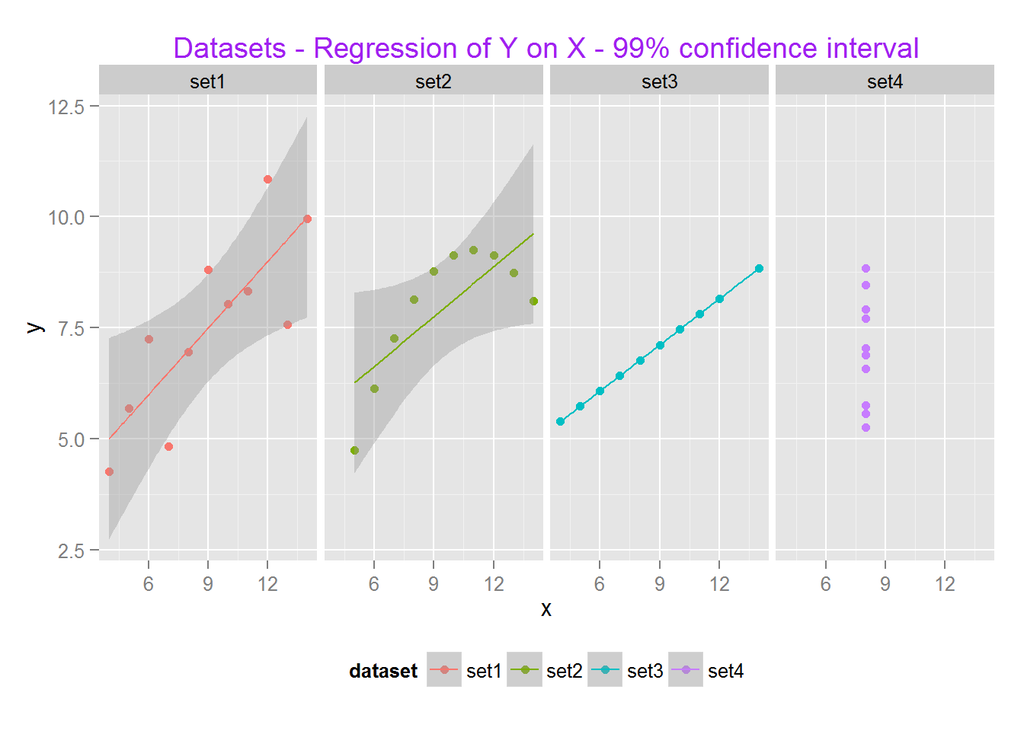

```r
#Regression of y on x with 99% confidence region
ggplot(df_cleandata,aes(x=x, y=y, color=dataset)) + geom_point(size=2) + geom_smooth(method=lm, level=0.99) + facet_grid(.~dataset) + labs(title="Datasets - Regression of Y on X - 99% confidence interval") + theme(plot.title = element_text(colour = "purple"), legend.position="bottom")
```

> **Observation:** When outliers removed, the datasets , set1 , set2 and set3 got similar trend line ( set1 and set2 got points scattered, but set3 has strictly linear trend). set4 has got constant x with increasing y values, a vertical line (undefined slope).